# day2_gsea_exercise

1. read and try to understand the implementation of GSEA algorithm (`day1_gsea_example.html`)
2. Use your own dataset or the p53 dataset (or pick one from https://www.gsea-msigdb.org/gsea/datasets.jsp), use gene sets in category “C5” and subcategory “GO:BP”, run GSEA with sample permutation and gene permutation (use the official GSEA software). Compare the results.
3. Use **clusterProfiler**, set gene-level score to t-value, log2fold change and -log10(p-value) and compare the results (`day1_clusterProfiler_gsea.html`, `day1_compare_ORA_GSEA.html`). Remember to also plot the distribution of the gene-level scores to see their differences (simply use `plot(sort(s))`.

dataset to use `p53.RData`. In this file, there are two objects:

- `expr`: the expression matrix
- `condition`: experimental design

steps:

- first calculate gene scores (by t-value, by -log10(p-value) or by log2fold change)
- then sort the gene score
- last use `gseGO()` to perform the analysis

Note, to calculate t-values or p-values from the matrix, you can use `apply()` and `t.test()` function:

```r
tvalue = apply(mat, 1, function(x) {
    x1  # x1 is the value in condition 1
    x2  # x2 is the value in condition 2
    t = t.test(x1, x2)
    t$statistic
})
pvalue = apply(mat, 1, function(x) {
    x1  # x1 is the value in condition 1
    x2  # x2 is the value in condition 2
    t = t.test(x1, x2)
    t$p.value
})
log2fc = apply(mat, 1, function(x) {
    x1  # x1 is the value in condition 1
    x2  # x2 is the value in condition 2
    log2(mean(x1)/mean(x2))
})
```

```r
load("p53.RData")
```

```r
convert_to_entrez_id = function(x, org_db = "org.Hs.eg.db") {
    if(is.matrix(x)) {
        map = cola:::guess_id_mapping(rownames(x), org_db = org_db)
        if(is.function(map)) {
            new_rn = map(rownames(x))
        } else {
            new_rn = map[rownames(x)]
        }
        l = is.na(new_rn)

        x = x[!l, , drop = FALSE]
        new_rn = new_rn[!l]

        x2 = do.call(rbind, tapply(1:nrow(x), new_rn, function(ind) {
            colMeans(x[ind, , drop = FALSE])
        }))
        return(x2)

    } else if(is.numeric(x)) {
        map = cola:::guess_id_mapping(names(x), org_db = org_db)
        x2 = x
        if(is.function(map)) {
            names(x2) = map(names(x))
        } else {
            names(x2) = map[names(x)]
        }
        x2 = x2[!is.na(names(x2))]
        x2 = tapply(x2, names(x2), mean)
        return(x2)
    } else {
        map = cola:::guess_id_mapping(x, org_db = org_db)
        if(is.function(map)) {
            x2 = map(x)
        } else {
            x2 = map[x]
        }
        x2 = x2[!is.na(x2)]
        x2 = unique(x2)
        return(x2)
    }
}
```

```r
expr = convert_to_entrez_id(expr)
```

```
## testing org.Hs.egENSEMBL...
```

```
## testing org.Hs.egREFSEQ...
```

```
## testing org.Hs.egSYMBOL...
##   gene id might be SYMBOL (p = 0.670)
```

```r
library(genefilter)
tdf = rowttests(expr, factor(condition))  # the second must be a "factor"
```

```r
m1 = expr[, condition == "WT"]
m2 = expr[, condition == "MUT"]

log2fc = log2( rowMeans(m2)/rowMeans(m1) )
tdf$log2fc = log2fc

tdf$log_p = -log10(tdf$p.value)*sign(tdf$log2fc)
```

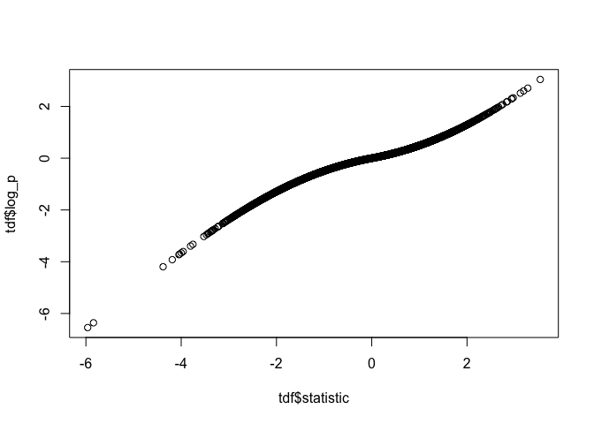

```r
#plot(tdf$statistic, tdf$log2fc)

plot(tdf$statistic, tdf$log_p)
```

```r
s = tdf$statistic
names(s) = rownames(tdf)   # s must have names (gene IDs)
s = sort(s, decreasing = TRUE)  # s must be pre-sorted
tb_gsea = gseGO(geneList = s,
                OrgDb = org.Hs.eg.db,
                ont   = "BP",
                pAdjustMethod = "BH")
```

```
## preparing geneSet collections...
```

```
## GSEA analysis...
```

```
## leading edge analysis...
```

```
## done...
```

```r
tb_gsea_tvalue = as.data.frame(tb_gsea)
```

```r
s = tdf$log2fc
names(s) = rownames(tdf)   # s must have names (gene IDs)
s = sort(s, decreasing = TRUE)  # s must be pre-sorted
tb_gsea = gseGO(geneList = s,
                OrgDb = org.Hs.eg.db,
                ont   = "BP",
                pAdjustMethod = "BH")
```

```
## preparing geneSet collections...
```

```
## GSEA analysis...
```

```
## leading edge analysis...
```

```
## done...
```

```r
tb_gsea_log2fc = as.data.frame(tb_gsea)


s = tdf$log_p
names(s) = rownames(tdf)   # s must have names (gene IDs)
s = sort(s, decreasing = TRUE)  # s must be pre-sorted
tb_gsea = gseGO(geneList = s,
                OrgDb = org.Hs.eg.db,
                ont   = "BP",
                pAdjustMethod = "BH")
```

```
## preparing geneSet collections...
```

```
## GSEA analysis...
```

```
## leading edge analysis...
```

```
## done...
```

```r
tb_gsea_log_p = as.data.frame(tb_gsea)
```

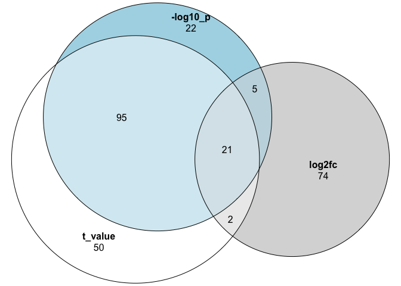

```r
library(eulerr)
plot(euler(list(t_value = tb_gsea_tvalue$ID,
                log2fc = tb_gsea_log2fc$ID,
                "-log10_p" = tb_gsea_log_p$ID)),
    quantities = TRUE)
```